# Part I - (Fordgo Bike Data Exploration)

## Introduction

This dataset contains information about individual rides as a result of bicycles used in the San Francisco area.

## Preliminary Wrangling

```python
import numpy as np
import pandas as pd
import matplotlib.pyplot as plt
import seaborn as sb
import datetime as dt
from datetime import datetime
%matplotlib inline
```

```python
bike = pd.read_csv('201902-fordgobike-tripdata.csv')
```

```python
bike.sample(5)
```

|  | duration_sec | start_time | end_time | start_station_id | start_station_name | start_station_latitude | start_station_longitude | end_station_id | end_station_name | end_station_latitude | end_station_longitude | bike_id | user_type | member_birth_year | member_gender | bike_share_for_all_trip | start_hour | end_hour |
| --- | --- | --- | --- | --- | --- | --- | --- | --- | --- | --- | --- | --- | --- | --- | --- | --- | --- | --- |
| 134832 | 369 | 2019-02-08 16:45:56.7020 | 2019-02-08 16:52:05.9830 | 284.0 | Yerba Buena Center for the Arts (Howard St at ... | 37.784872 | -122.400876 | 16.0 | Steuart St at Market St | 37.794130 | -122.394430 | 1911 | Subscriber | 1972.0 | Male | No | 16 | 16 |
| 93632 | 1910 | 2019-02-15 17:04:13.6410 | 2019-02-15 17:36:04.2610 | 240.0 | Haste St at Telegraph Ave | 37.866043 | -122.258804 | 240.0 | Haste St at Telegraph Ave | 37.866043 | -122.258804 | 5116 | Customer | NaN | NaN | No | 17 | 17 |
| 154707 | 916 | 2019-02-06 09:19:53.1290 | 2019-02-06 09:35:09.6590 | 25.0 | Howard St at 2nd St | 37.787522 | -122.397405 | 41.0 | Golden Gate Ave at Polk St | 37.781270 | -122.418740 | 5023 | Subscriber | 1979.0 | Female | No | 9 | 9 |
| 17102 | 483 | 2019-02-27 07:36:47.1430 | 2019-02-27 07:44:50.7360 | 62.0 | Victoria Manalo Draves Park | 37.777791 | -122.406432 | 101.0 | 15th St at Potrero Ave | 37.767079 | -122.407359 | 6588 | Subscriber | 1996.0 | Male | No | 7 | 7 |
| 105610 | 324 | 2019-02-13 22:08:57.9070 | 2019-02-13 22:14:22.7770 | 255.0 | Virginia St at Shattuck Ave | 37.876573 | -122.269528 | 246.0 | Berkeley Civic Center | 37.869060 | -122.270556 | 4546 | Subscriber | 1995.0 | Male | No | 22 | 22 |

```python
bike.info()
```

```
<class 'pandas.core.frame.DataFrame'>
RangeIndex: 183412 entries, 0 to 183411
Data columns (total 18 columns):
 #   Column                   Non-Null Count   Dtype
---  ------                   --------------   -----
 0   duration_sec             183412 non-null  int64
 1   start_time               183412 non-null  object
 2   end_time                 183412 non-null  object
 3   start_station_id         183215 non-null  float64
 4   start_station_name       183215 non-null  object
 5   start_station_latitude   183412 non-null  float64
 6   start_station_longitude  183412 non-null  float64
 7   end_station_id           183215 non-null  float64
 8   end_station_name         183215 non-null  object
 9   end_station_latitude     183412 non-null  float64
 10  end_station_longitude    183412 non-null  float64
 11  bike_id                  183412 non-null  int64
 12  user_type                183412 non-null  object
 13  member_birth_year        175147 non-null  float64
 14  member_gender            175147 non-null  object
 15  bike_share_for_all_trip  183412 non-null  object
 16  start_hour               183412 non-null  int64
 17  end_hour                 183412 non-null  int64
dtypes: float64(7), int64(4), object(7)
memory usage: 25.2+ MB
```

```python
print(bike.shape)
print(bike.dtypes)
```

```
(183412, 18)
duration_sec                 int64
start_time                  object
end_time                    object
start_station_id           float64
start_station_name          object
start_station_latitude     float64
start_station_longitude    float64
end_station_id             float64
end_station_name            object
end_station_latitude       float64
end_station_longitude      float64
bike_id                      int64
user_type                   object
member_birth_year          float64
member_gender               object
bike_share_for_all_trip     object
start_hour                   int64
end_hour                     int64
dtype: object
```

```python
bike.describe()
```

|  | duration_sec | start_station_id | start_station_latitude | start_station_longitude | end_station_id | end_station_latitude | end_station_longitude | bike_id | member_birth_year | start_hour | end_hour |
| --- | --- | --- | --- | --- | --- | --- | --- | --- | --- | --- | --- |
| count | 183412.000000 | 183215.000000 | 183412.000000 | 183412.000000 | 183215.000000 | 183412.000000 | 183412.000000 | 183412.000000 | 175147.000000 | 183412.000000 | 183412.000000 |
| mean | 726.078435 | 138.590427 | 37.771223 | -122.352664 | 136.249123 | 37.771427 | -122.352250 | 4472.906375 | 1984.806437 | 13.458421 | 13.614769 |
| std | 1794.389780 | 111.778864 | 0.099581 | 0.117097 | 111.515131 | 0.099490 | 0.116673 | 1664.383394 | 10.116689 | 4.724978 | 4.739638 |
| min | 61.000000 | 3.000000 | 37.317298 | -122.453704 | 3.000000 | 37.317298 | -122.453704 | 11.000000 | 1878.000000 | 0.000000 | 0.000000 |
| 25% | 325.000000 | 47.000000 | 37.770083 | -122.412408 | 44.000000 | 37.770407 | -122.411726 | 3777.000000 | 1980.000000 | 9.000000 | 9.000000 |
| 50% | 514.000000 | 104.000000 | 37.780760 | -122.398285 | 100.000000 | 37.781010 | -122.398279 | 4958.000000 | 1987.000000 | 14.000000 | 14.000000 |
| 75% | 796.000000 | 239.000000 | 37.797280 | -122.286533 | 235.000000 | 37.797320 | -122.288045 | 5502.000000 | 1992.000000 | 17.000000 | 18.000000 |
| max | 85444.000000 | 398.000000 | 37.880222 | -121.874119 | 398.000000 | 37.880222 | -121.874119 | 6645.000000 | 2001.000000 | 23.000000 | 23.000000 |

```python
bike.isna().sum()
```

```
duration_sec                  0
start_time                    0
end_time                      0
start_station_id            197
start_station_name          197
start_station_latitude        0
start_station_longitude       0
end_station_id              197
end_station_name            197
end_station_latitude          0
end_station_longitude         0
bike_id                       0
user_type                     0
member_birth_year          8265
member_gender              8265
bike_share_for_all_trip       0
start_hour                    0
end_hour                      0
dtype: int64
```

```python
bike.duplicated().sum()
```

```
0
```

### What is/are the main feature(s) of interest in your dataset?

I'm most interested in figuring out which properties are best in relation to the date, time, user type, and travel time of the users in the dataset.

### What features in the dataset do you think will help support your investigation into your feature(s) of interest?

My expectation is that the most used days are weekdays, and the average age of those who use weekends may increase. Because the high average age group is likely to use bicycles to have a pleasant time on the weekend.

## Univariate Exploration

I'll start by looking at the distribution of the main variable of interest:user type.

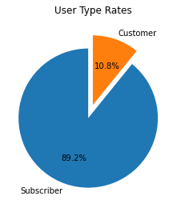

```python
def plot_pie_chart (data_source, column, title):
    sorted_counts = bike['user_type'].value_counts()
    plt.pie(sorted_counts, labels = sorted_counts.index, startangle = 90,explode=[0.2,0],autopct='%1.1f%%')
    plt.title("User Type Rates")
plot_pie_chart(bike, "user_type", "User Type Rates")
```

The most user type was subscribers with ½ 89.2.

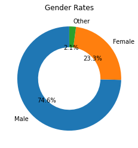

```python
def bagel_pie_chart (data_source, column, title):
    gender_counts = bike['member_gender'].value_counts()
    plt.pie(gender_counts, labels = gender_counts.index, startangle = 90,autopct='%1.1f%%',wedgeprops = {'width' : 0.4})
    plt.title("Gender Rates")

bagel_pie_chart(bike, "member_gender", "Gender Rates")
```

According to gender, the highest number of users was male with ½ 74.6.

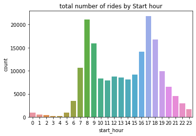

```python
def bar_chart(data_source, column, title):
    bike['start_hour']=pd.to_datetime(bike['start_time']).dt.hour
    order = np.arange(0,24)
    sb.countplot(x=bike["start_hour"],order=order)
    plt.title("total number of rides by Start hour")
bar_chart(bike,"start_hour","total number of rides by Start hour")
```

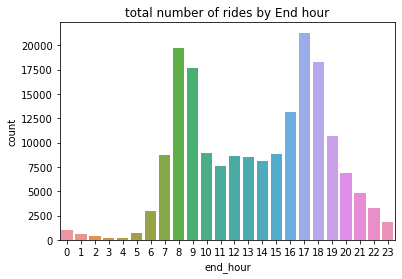

```python
def bar_chart(data_source, column, title):
    bike['end_hour']=pd.to_datetime(bike['end_time']).dt.hour
    order = np.arange(0,24)
    sb.countplot(x=bike["end_hour"],order=order)
    plt.title("total number of rides by End hour")
bar_chart(bike,"end_hour","total number of rides by end hour")
```

When we look at the start and end times, the most bicycle traffic occurred between business hours (07-18).

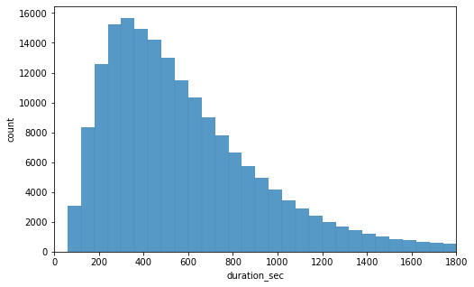

```python
bins = np.arange(0, bike['duration_sec'].max()+60,60)
plt.figure(figsize=[8, 5])
sb.histplot(data = bike, x = 'duration_sec', bins = bins)
plt.xlabel('duration_sec')
plt.ylabel('count')
plt.xlim(0,1800)
plt.show()
```

When we look at the graph, we see that people mostly use bicycles for short periods of time.

```
(18.0, 80.0)
```

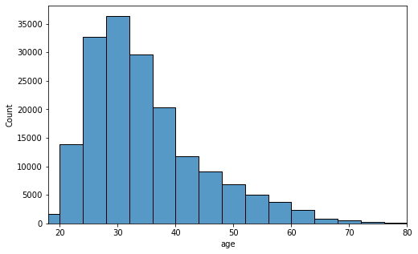

```python
bike['age']=(2019-bike['member_birth_year'])
bins = np.arange(0, bike['age'].max()+4,4)
plt.figure(figsize=[8, 5])
sb.histplot(data = bike, x = 'age', bins = bins)
plt.xlim(18,80)
```

It is obvious that those who use the bike the most are in their 30s.

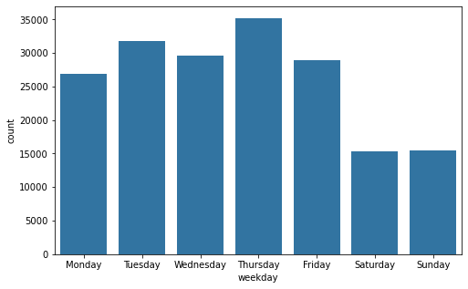

```python
bike['weekday'] = pd.to_datetime(bike["start_time"]).dt.day_name()
plt.figure(figsize=[8, 5])
base_color = sb.color_palette()[0]
sb.countplot(data=bike, x='weekday', order= ['Monday', 'Tuesday', 'Wednesday','Thursday', 'Friday','Saturday','Sunday'],color=base_color)
```

We see that bicycles are used the most on thursday.

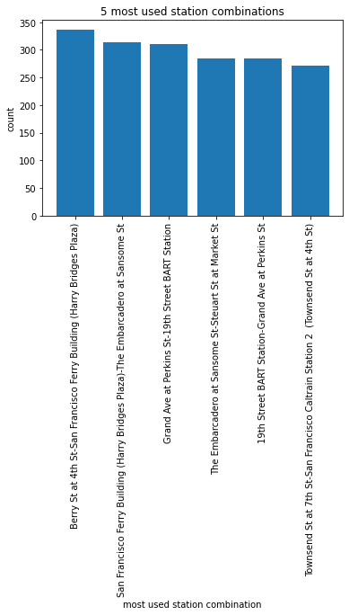

```python
pivot=bike.pivot_table(index=['start_station_name',"end_station_name"]
                   ,aggfunc="count").sort_values(by='start_station_id', ascending=False).reset_index().head(6)
pivot['combination']=pivot['start_station_name'] + '-' + pivot["end_station_name"]
plt.bar(data=pivot,x='combination',height="bike_id")
plt.xticks(rotation=90)
plt.xlabel("most used station combination")
plt.ylabel("count")
plt.title('5 most used station combinations')
```

### Discuss the distribution(s) of your variable(s) of interest. Were there any unusual points? Did you need to perform any transformations?

Users are mostly subscribers, and mostly men use bicycles. Bicycles are mostly used between business hours (7-18). It is used more on weekdays than on weekends, which may be because most people prefer cycling to and from work. they prefer bicycles for a short time, mostly those in their 30s.

### Of the features you investigated, were there any unusual distributions? Did you perform any operations on the data to tidy, adjust, or change the form of the data? If so, why did you do this?

I added age, hour and day columns from the data because I produced more meaningful results on the data. Especially after a certain age, I had the opportunity to discover how people use their bicycles and the times they use bicycles the most.

## Bivariate Exploration

```
(18.0, 90.0)
```

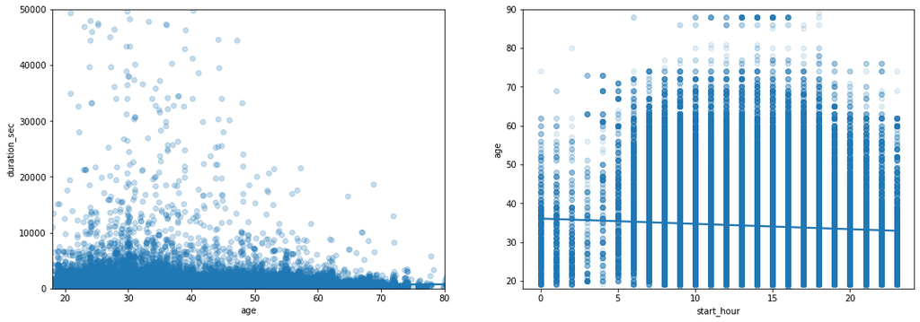

```python
plt.figure(figsize = [18, 6])
plt.subplot(1, 2, 1)
sb.regplot(data = bike, x = 'age', y = 'duration_sec', x_jitter=0.3,scatter_kws={'alpha':1/4})
plt.xlim(18,80)
plt.ylim(0,50000)
plt.subplot(1, 2, 2)
sb.regplot(data = bike, x ='start_hour' , y = 'age',scatter_kws={'alpha':1/8})
plt.ylim(18,90)
```

I could not see a significant difference between the correlation graphs above, but we can see that young people between 22 and 03 o'clock use it more and and we're seeing the pre-50 population arrive at longer travel times

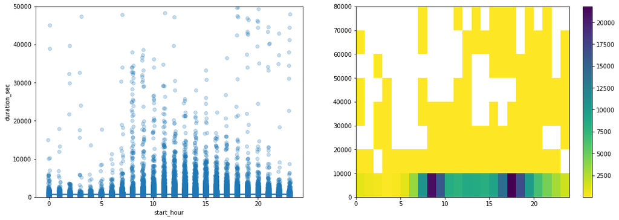

```python
plt.figure(figsize = [18, 6])
plt.subplot(1, 2, 1)
sb.regplot(data = bike, x ='start_hour' , y = 'duration_sec', x_jitter=0.1,scatter_kws={'alpha':1/4})
plt.ylim(0,50000)
plt.subplot(1, 2, 2)
bins_x = np.arange(0, 24+1, 1)
bins_y = np.arange(0, 80000+10000,10000)
a=plt.hist2d(data = bike, x ='start_hour', y = 'duration_sec',cmin=0.3,cmap='viridis_r', bins = [bins_x, bins_y])
plt.colorbar()
```

I couldn't see any significant difference between the correlation graphs above, but we can see that between 08 and 17 o'clock, bicycles are used more, and in the morning and evening hours, people use bicycles for longer travel.

```
(0.0, 5000.0)
```

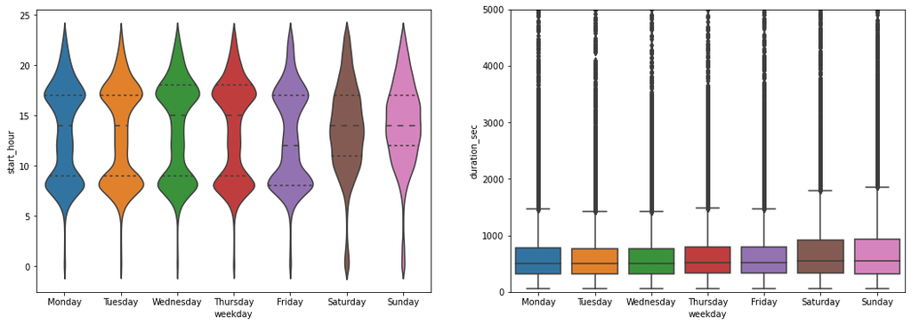

```python
plt.figure(figsize = [18, 6])
plt.subplot(1, 2, 1)
order=['Monday', 'Tuesday', 'Wednesday','Thursday', 'Friday','Saturday','Sunday']
sb.violinplot(data=bike, x='weekday', y='start_hour',inner='quartile',order=order)
plt.subplot(1, 2, 2)
sb.boxplot(data=bike, x='weekday', y= 'duration_sec',order=order)
plt.ylim(0,5000)
```

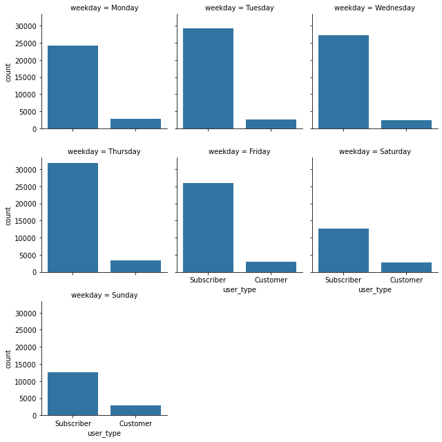

```python
g = sb.FacetGrid(data =bike, col = "weekday", col_wrap=3, sharey=True, col_order=['Monday', 'Tuesday', 'Wednesday','Thursday', 'Friday','Saturday','Sunday'])
g.map(sb.countplot, "user_type",order=["Subscriber", "Customer"] )
```

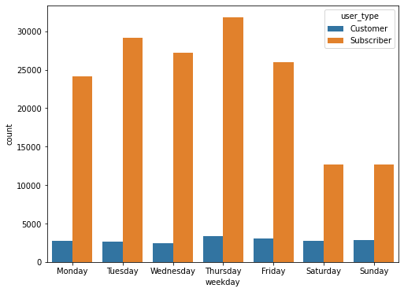

```python
plt.figure(figsize = [8, 6])
chart=sb.countplot(data = bike, x = "weekday", hue = "user_type", order= ['Monday', 'Tuesday', 'Wednesday','Thursday', 'Friday','Saturday','Sunday'])
```

When we look at the graphs, we see that the subscribers use a little less on Monday and a decrease in the use of bicycles on the weekends. This may be because they are busy at the beginning of the week and they want to rest on the weekend.

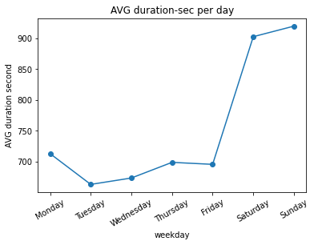

```python
plt.figure(figsize = [8, 5])
d=bike.pivot_table(index=["weekday"],values='duration_sec'
                   ,aggfunc=[np.mean]).reset_index()
cats = ['Monday', 'Tuesday', 'Wednesday', 'Thursday', 'Friday', 'Saturday', 'Sunday']
d['weekday'] = pd.Categorical(d['weekday'], categories=cats, ordered=True)
d = d.sort_values('weekday')
d.plot(kind="line",x="weekday",marker='o',legend=None)
plt.xticks(rotation=30)
plt.ylabel("AVG duration second")
plt.title("AVG duration-sec per day")
```

### Talk about some of the relationships you observed in this part of the investigation. How did the feature(s) of interest vary with other features in the dataset?

We see that young people between 22-03 hours use it more and the population under 50 comes with longer travel times. We can see that bicycles are used more between 08-17 hours, and people use bicycles for longer journeys in the morning and evening hours.

## Multivariate Exploration

```
(18.0, 80.0)
```

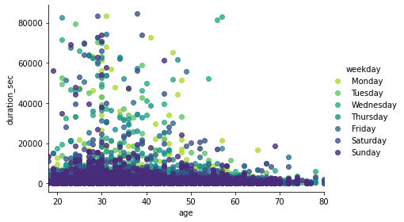

```python
plt.figure(figsize = [8, 5])
order= ['Monday', 'Tuesday', 'Wednesday', 'Thursday', 'Friday', 'Saturday', 'Sunday']
bike['weekday'] = pd.Categorical(bike['weekday'], categories=order, ordered=True)
bike= bike.sort_values('weekday')
g = sb.FacetGrid(data = bike, hue = "weekday",
               size = 4, aspect = 1.5, palette = 'viridis_r')
g.map(sb.regplot,'age','duration_sec', fit_reg = False)
g.add_legend()
plt.xlim(18,80)
```

When we look at the graph, it shows that short-term bike rides are made every day of the week.

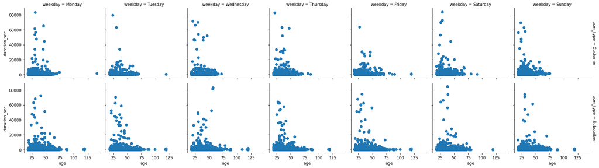

```python
g = sb.FacetGrid(data =bike, col = 'weekday', row = 'user_type', margin_titles = True,col_order=['Monday', 'Tuesday', 'Wednesday','Thursday', 'Friday','Saturday','Sunday'])
g.map(plt.scatter, 'age','duration_sec')
```

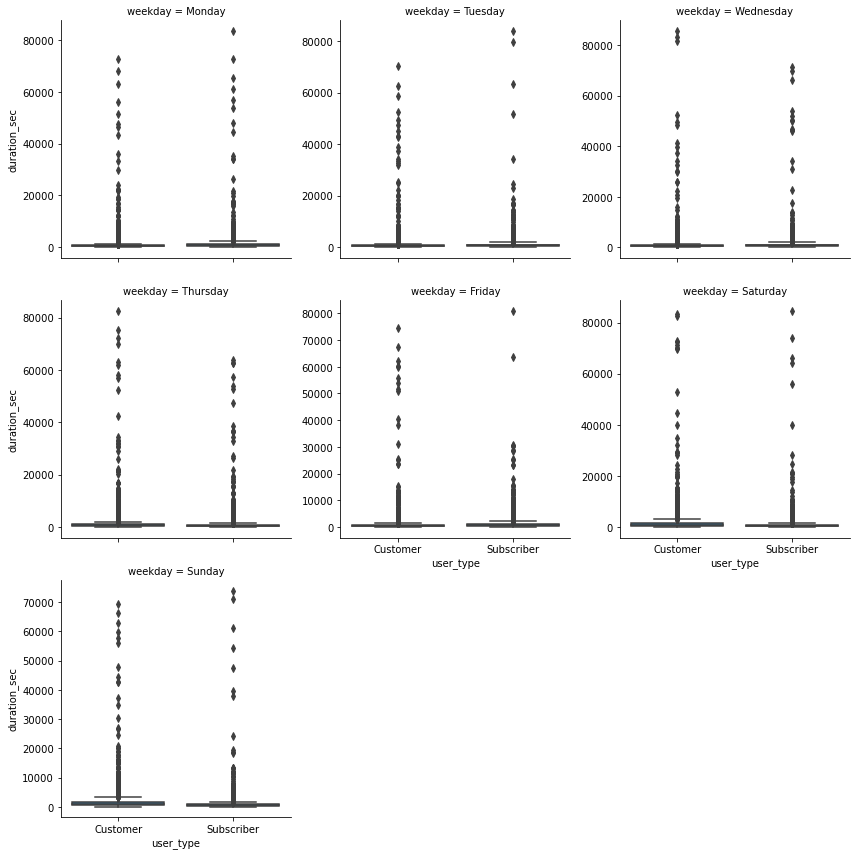

```python
g = sb.FacetGrid(data = bike, col = 'weekday', col_wrap=3,sharey=False,size = 4,col_order=['Monday', 'Tuesday', 'Wednesday','Thursday', 'Friday','Saturday','Sunday'])
g.map(sb.boxplot, "user_type",'duration_sec')
```

### Talk about some of the relationships you observed in this part of the investigation. Were there features that strengthened each other in terms of looking at your feature(s) of interest?

It shows that bike company users do short-term bike rides every day of the week and have users on the younger age scale and it is possible to see that subscribers behave more consistently and users of all ages, but it is a bit difficult to see them in customers

### Were there any interesting or surprising interactions between features?

It may be that there is a negative correlation between age and journey time, both between users and customers.

## Conclusions

The results of my analysis focused on discovering and visualizing the usage habits of age-related subscribers and consumers on the days of the week and at certain times of the day.that the company is predominantly male users, mostly 30s. that it is used more frequently but in short time intervals on weekdays, longer and less on weekends. There was a negative relationship between age and travel time.

```python
bike.to_csv("fordgobikelast.csv", header=True, index=None)
```